# Introduction to Igraph

Benjamin Ortiz Ulloa

1/26/2019

## Getting Started

**igraph** is an open source library for graph analysis written in C/C++. It has api wrappers written in R and Python. While there are other awesome packages in R like **statnet**’s **sna** package, **igraph** is the coolest and that is why we are covering it here today.

Before we do anything however, we will need to install and load the package.

```r
#install.packages(c('igraph', 'nycflights13', 'purrr'))
library(igraph)
```

## Creating a graph from nothing

We can build a graph from scratch by simply initializing an empty graph object. This graph object has no nodes and no edges. It is a blank canvas for us to work on.

```r
#initialize a graph
g <- graph.empty(n = 0, directed = T)

g
```

```
## IGRAPH 28b08fe D--- 0 0 --
## + edges from 28b08fe:
```

Please note the **D** in the summary. This means we have a **directed** graph and that every edge we add to it will have direction. If we entered `directed = F`, then the summary would display a **U**. The two **0**s represent the number of **vertices** and **edges** respectively.

We can add attributes to the graph for clarification. This is useful if we want to share this graph with contributors or our future selves.

```r
g$name <- 'My First Graph'
g$info <- "This is the first graph we wrote for Data Days Texas 2019's tutorial on igraph!"
g$author <- 'Me!'

g
```

```
## IGRAPH 28b08fe D--- 0 0 -- My First Graph
## + attr: name (g/c), info (g/c), author (g/c)
## + edges from 28b08fe:
```

```r
#access information like you would a data frame
g$info
```

```
## [1] "This is the first graph we wrote for Data Days Texas 2019's tutorial on igraph!"
```

### Setting & Getting Vertices

We can start adding vertices to the empty graph once it is initialized. This is done by providing the number of nodes we want and a list of node attributes.

```r
#add vertices
g <- add_vertices(graph = g, nv = 5, attr = list(name = letters[1:5],
                                                 type = c('vowel', rep('consonant', 3), 'vowel')))
g
```

```
## IGRAPH fe8212a DN-B 5 0 -- My First Graph
## + attr: name (g/c), info (g/c), author (g/c), name (v/c), type
## | (v/c)
## + edges from fe8212a (vertex names):
```

The **N** in the summary means that the vertices have a **name** attribute. **name** has a special utility for a graph which we will discuss shortly. The **B** signals that the graph is a **bipartite** graph. This comes up when the vertices have a **type** attribute.

We can access a graph’s vertices

```r
#a vertex object is really just a vector of vertices
V(g)
```

```
## + 5/5 vertices, named, from fe8212a:
## [1] a b c d e
```

```r
#we can get information in tabular format if we use [[]]
V(g)[[]]
```

```
## + 5/5 vertices, named, from fe8212a:
##   name      type
## 1    a     vowel
## 2    b consonant
## 3    c consonant
## 4    d consonant
## 5    e     vowel
```

```r
#we can even filter the vertices by their attributes
V(g)[[type == 'vowel']]
```

```
## + 2/5 vertices, named, from fe8212a:
##   name  type
## 1    a vowel
## 5    e vowel
```

Vertex objects are simply vectors of vertices. Attributes can be retrieved by using methods similar to those of a data frame.

```r
V(g)$type
```

```
## [1] "vowel"     "consonant" "consonant" "consonant" "vowel"
```

We can even iterate over them, however, using base _apply methods isn’t very helpful. It is better to use **purrr**’s mapping functions.

```r
#iterating over vertex object simply gives you the id
lapply(V(g), function(x){x})
```

```
## $a
## [1] 1
##
## $b
## [1] 2
##
## $c
## [1] 3
##
## $d
## [1] 4
##
## $e
## [1] 5
```

```r
#however, you can iterate over the attributes
sapply(V(g)$type, function(x){paste("I'm a ", x)})
```

```
##              vowel          consonant          consonant
##     "I'm a  vowel" "I'm a  consonant" "I'm a  consonant"
##          consonant              vowel
## "I'm a  consonant"     "I'm a  vowel"
```

```r
### you can work with all attributes of a vertex with purrrr
purrr::map_chr(V(g), function(x){paste(x$name, ' is a ', x$type)})
```

```
##                    a                    b                    c
##     "a  is a  vowel" "b  is a  consonant" "c  is a  consonant"
##                    d                    e
## "d  is a  consonant"     "e  is a  vowel"
```

### Setting & Getting Edges

Adding edges to a graph is similar to adding vertices. One major difference howeer, is that the *edges* parameter takes a pairwise vector of vertices. For directed graphs the first vertex is where the edge is coming **from** and the second vertex is where the edge is going **to**. The order does not matter for undirected graphs.

```r
set.seed(4321)
g <- add_edges(graph = g,
               edges = c('b', 'e',
                         'e', 'a',
                         'a', 'd',
                         'c', 'a'),
               attr = list(weight = runif(4, 0, 1)))

g
```

```
## IGRAPH 143f226 DNWB 5 4 -- My First Graph
## + attr: name (g/c), info (g/c), author (g/c), name (v/c), type
## | (v/c), weight (e/n)
## + edges from 143f226 (vertex names):
## [1] b->e e->a a->d c->a
```

The **W** shown in the summary is the **weight** attribute. The significance of this value depends on the functions used and the particular graph application.

We will not focus on plotting at this workshop, but now that we have a graph with both edges and vertices, it is worth showing how it is done. Please note that the cartesian coordinates (x and y coordinates) do not hold much significance and that the nodes and edges are positioned to reduce overlap. Also, please note that the euclidean distance between connected nodes are different for each edge. What do you thing this suggests about the edges weight?

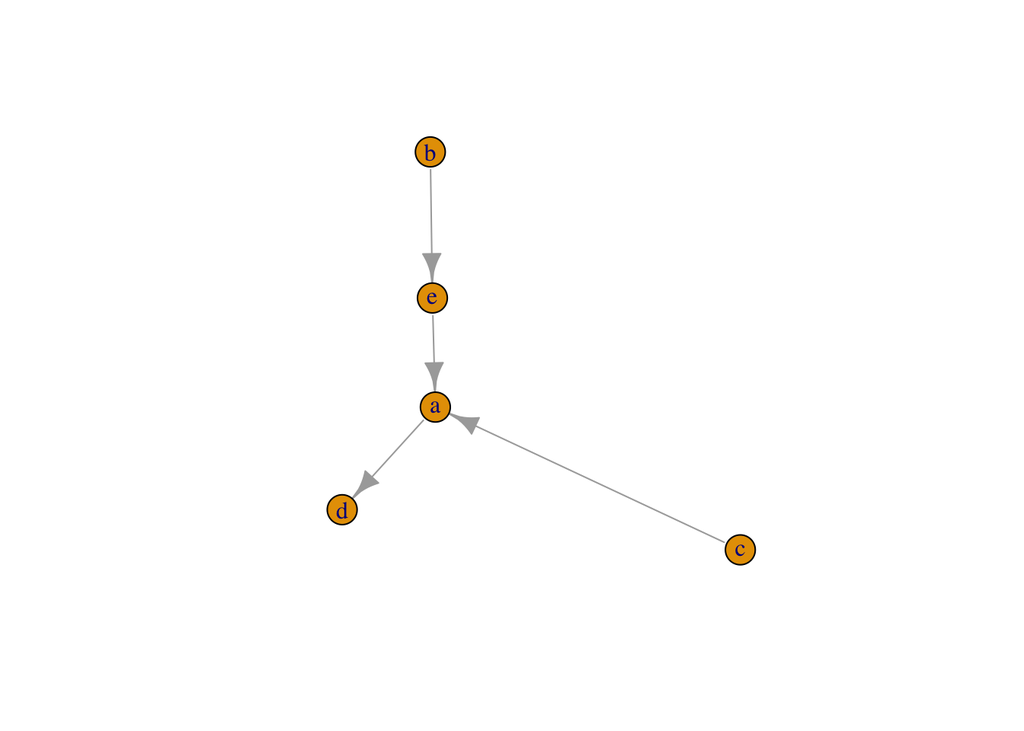

```r
set.seed(4321)
plot(g)
```

Everything we have done with the vector of vertices we can also do with the vector of edges.

```r
E(g)
```

```
## + 4/4 edges from 143f226 (vertex names):
## [1] b->e e->a a->d c->a
```

```r
E(g)[[]]
```

```
## + 4/4 edges from 143f226 (vertex names):
##   tail head tid hid     weight
## 1    b    e   2   5 0.33477802
## 2    e    a   5   1 0.90913948
## 3    a    d   1   4 0.41152969
## 4    c    a   3   1 0.04384097
```

```r
E(g)[[weight >= .5]]
```

```
## + 1/4 edge from 143f226 (vertex names):
##   tail head tid hid    weight
## 2    e    a   5   1 0.9091395
```

```r
E(g)$weight
```

```
## [1] 0.33477802 0.90913948 0.41152969 0.04384097
```

```r
purrr::map_chr(E(g), function(x){x})
```

```
## [1] "1" "2" "3" "4"
```

There are some other cool functions we have to explore and filter the edges of a graph. These functions are helpful for filtering down information stored in edges.

```r
#where are the edges coming from?
tail_of(graph = g, es = E(g))
```

```
## + 4/5 vertices, named, from 143f226:
## [1] b e a c
```

```r
#where are the edges going to?
head_of(graph = g, es = E(g))
```

```
## + 4/5 vertices, named, from 143f226:
## [1] e a d a
```

```r
#what are edges that leave from 'e' and go to 'a'
E(g)['e' %->% 'a']
```

```
## + 1/4 edge from 143f226 (vertex names):
## [1] e->a
```

```r
#what are edges that go to 'a' from 'e'
E(g)['a' %<-% 'e']
```

```
## + 1/4 edge from 143f226 (vertex names):
## [1] e->a
```

```r
#what are edges that go to 'a' from any vertex?
E(g)['a' %<-% V(g)]
```

```
## + 2/4 edges from 143f226 (vertex names):
## [1] e->a c->a
```

```r
E(g)[to('a')]
```

```
## + 2/4 edges from 143f226 (vertex names):
## [1] e->a c->a
```

```r
#what are edges that leave from 'a' to any vertex?
E(g)[from('a')]
```

```
## + 1/4 edge from 143f226 (vertex names):
## [1] a->d
```

```r
#what are edges that either leave from or go to 'a'?
E(g)['a' %--% V(g)]
```

```
## + 3/4 edges from 143f226 (vertex names):
## [1] e->a a->d c->a
```

## Using Magrittr’s pipe

**Magrittr**’s pipe (`%>%`) function is automatically loaded with igraph. While some may consider the use of a pipe a stylistic decision, others (myself) consider it a god send that minimizes the number of nested functions, get’s rid of unnecessary naming, and allows us to incrementally build an object as we explore it.

```r
# this is the graph we made in the previous section
set.seed(4321)
g <- graph.empty(n = 0, directed = T)
g <- add_vertices(graph = g, nv = 5, attr = list(name = letters[1:5],
                                                 type = c('vowel', rep('consonant', 3), 'vowel')))
g <- add_edges(graph = g,
               edges = c('b', 'e',
                         'e', 'a',
                         'a', 'd',
                         'c', 'a'),
               attr = list(weight = runif(4, 0, 1)))

V(g)[[]]
```

```
## + 5/5 vertices, named, from c4deca4:
##   name      type
## 1    a     vowel
## 2    b consonant
## 3    c consonant
## 4    d consonant
## 5    e     vowel
```

```r
E(g)[[]]
```

```
## + 4/4 edges from c4deca4 (vertex names):
##   tail head tid hid     weight
## 1    b    e   2   5 0.33477802
## 2    e    a   5   1 0.90913948
## 3    a    d   1   4 0.41152969
## 4    c    a   3   1 0.04384097
```

The following code does the same thing as the above code. Please note that the graph is simply called **g** and so removing the repetitive assignments (`<-`) doesn’t necessarily save us typing and space. However, a lot of the times our scripts will have more descriptive (i.e. longer) names and continually typing them into a function can become burdensome.

```r
set.seed(4321)
g <- graph.empty(n = 0, directed = T) %>%
  add_vertices(nv = 5, attr = list(name = letters[1:5],
                                   type = c('vowel', rep('consonant', 3), 'vowel'))) %>%
  add_edges(edges = c('b', 'e',
                      'e', 'a',
                      'a', 'd',
                      'c', 'a'),
            attr = list(weight = runif(4, 0, 1)))

V(g)[[]]
```

```
## + 5/5 vertices, named, from 5ce783e:
##   name      type
## 1    a     vowel
## 2    b consonant
## 3    c consonant
## 4    d consonant
## 5    e     vowel
```

```r
E(g)[[]]
```

```
## + 4/4 edges from 5ce783e (vertex names):
##   tail head tid hid     weight
## 1    b    e   2   5 0.33477802
## 2    e    a   5   1 0.90913948
## 3    a    d   1   4 0.41152969
## 4    c    a   3   1 0.04384097
```

Other than saving us from typing, the pipe does help us streamline common graph functions and ensures that we are using vertices and edges from the same graph.

```r
g %>%
  {. - E(.)[weight <= .4]} %>% #remove edges with low weight
  {. - V(.)[degree(.) == 0]} #remove unconnected vertices
```

```
## IGRAPH f8a95a1 DNWB 3 2 --
## + attr: name (v/c), type (v/c), weight (e/n)
## + edges from f8a95a1 (vertex names):
## [1] e->a a->d
```

The below is a common error

```r
toRemove <- g - E(g)[weight <= .4]
g - E(toRemove)
```

```
## Error in as.igraph.es(graph, edges): Cannot use an edge sequence from another graph.
```

## Creating a graph from a matrix

Building a graph from scratch can get tedious. Luckily, we can use data from other formats to create a graph. A common transformation is creating a graph from a matrix. Generally, for non-bipartite graphs, the rownames should match the column names.

```r
set.seed(4321)
m <- matrix(sample(c(0, 1), 5*5, T), nrow = 5, ncol = 5)
rownames(m) <- letters[1:5]
colnames(m) <- letters[1:5]

m
```

```
##   a b c d e
## a 0 1 1 0 0
## b 1 1 0 1 1
## c 0 1 0 0 1
## d 0 0 1 0 1
## e 1 0 1 0 0
```

For directed graphs, the rows represent where the edges are coming from and the columns represent where the edges are going to.

```r
g <- graph_from_adjacency_matrix(adjmatrix = m, mode = 'directed')

g
```

```
## IGRAPH cb891ff DN-- 5 12 --
## + attr: name (v/c)
## + edges from cb891ff (vertex names):
##  [1] a->b a->c b->a b->b b->d b->e c->b c->e d->c d->e e->a e->c
```

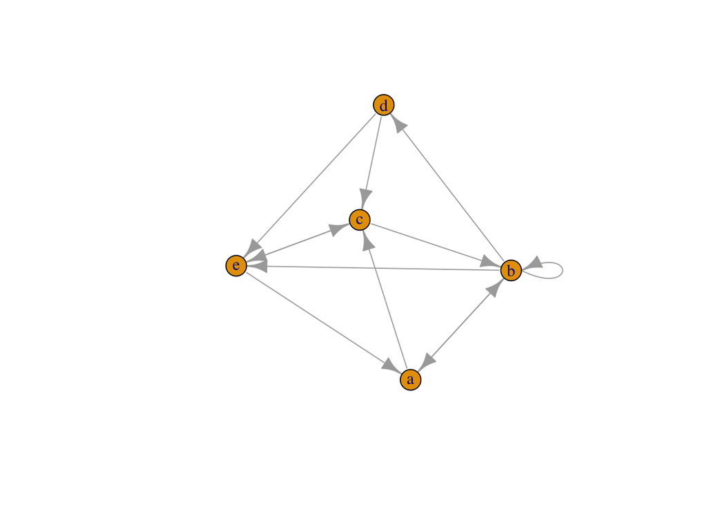

```r
set.seed(4321)
plot(g)
```

You can also convert a graph back into a matrix.

```r
as_adjacency_matrix(g)
```

```
## 5 x 5 sparse Matrix of class "dgCMatrix"
##   a b c d e
## a . 1 1 . .
## b 1 1 . 1 1
## c . 1 . . 1
## d . . 1 . 1
## e 1 . 1 . .
```

A bipart graph can be created if the rownames are different from the column names. The rows and columns would represent different types of nodes.

```r
colnames(m) <- LETTERS[1:5]
g <- graph_from_incidence_matrix(m, directed = F)

g
```

```
## IGRAPH 18968ea UN-B 10 12 --
## + attr: type (v/l), name (v/c)
## + edges from 18968ea (vertex names):
##  [1] a--B a--C b--A b--B b--D b--E c--B c--E d--C d--E e--A e--C
```

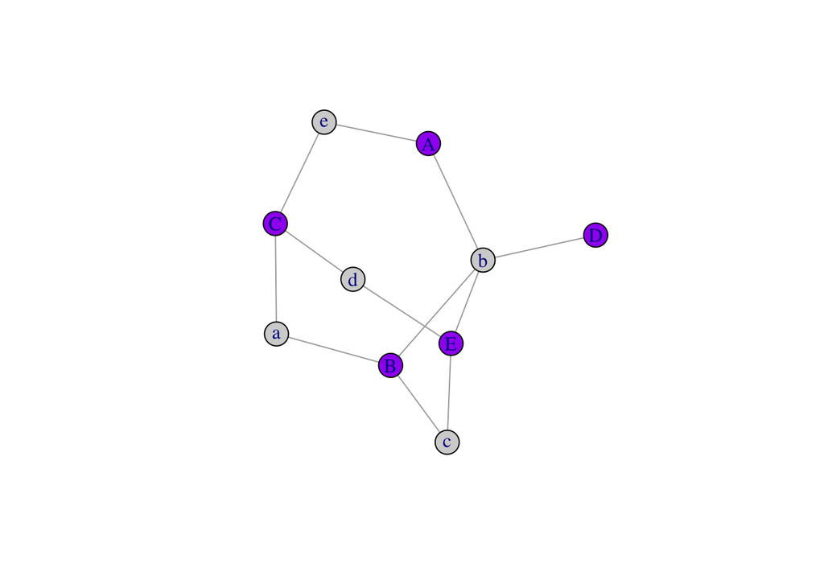

```r
set.seed(4321)
g %>%
  plot(
    vertex.color = ifelse(V(.)$type, 'purple', 'lightgrey')
  )
```

Again, this graph can be converted back to a matrix.

```r
as_incidence_matrix(g)
```

```
##   A B C D E
## a 0 1 1 0 0
## b 1 1 0 1 1
## c 0 1 0 0 1
## d 0 0 1 0 1
## e 1 0 1 0 0
```

Information from one matrix graph can be added to another matrix graph by calling transposing the ends of a graph’s edges and adding it to the other graph.

```r
ends(g, E(g))
```

```
##       [,1] [,2]
##  [1,] "a"  "B"
##  [2,] "a"  "C"
##  [3,] "b"  "A"
##  [4,] "b"  "B"
##  [5,] "b"  "D"
##  [6,] "b"  "E"
##  [7,] "c"  "B"
##  [8,] "c"  "E"
##  [9,] "d"  "C"
## [10,] "d"  "E"
## [11,] "e"  "A"
## [12,] "e"  "C"
```

```r
ends(g, E(g)) %>% t
```

```
##      [,1] [,2] [,3] [,4] [,5] [,6] [,7] [,8] [,9] [,10] [,11] [,12]
## [1,] "a"  "a"  "b"  "b"  "b"  "b"  "c"  "c"  "d"  "d"   "e"   "e"
## [2,] "B"  "C"  "A"  "B"  "D"  "E"  "B"  "E"  "C"  "E"   "A"   "C"
```

```r
g + edges(ends(g, E(g)) %>% t)
```

```
## IGRAPH 28d0165 UN-B 10 24 --
## + attr: type (v/l), name (v/c)
## + edges from 28d0165 (vertex names):
##  [1] a--B a--C b--A b--B b--D b--E c--B c--E d--C d--E e--A e--C a--B a--C
## [15] b--A b--B b--D b--E c--B c--E d--C d--E e--A e--C
```

## Creating a graph from a data frame

Before we start creating graphs from data frames, let’s create a data frame from a graph now that we have a simple graph.

```r
as_data_frame(g, what = 'both')
```

```
## $vertices
##    type name
## a FALSE    a
## b FALSE    b
## c FALSE    c
## d FALSE    d
## e FALSE    e
## A  TRUE    A
## B  TRUE    B
## C  TRUE    C
## D  TRUE    D
## E  TRUE    E
##
## $edges
##    from to
## 1     a  B
## 2     a  C
## 3     b  A
## 4     b  B
## 5     b  D
## 6     b  E
## 7     c  B
## 8     c  E
## 9     d  C
## 10    d  E
## 11    e  A
## 12    e  C
```

If we entered **edges** or **vertices** in the `what` parameter, then we would have gottend the respective data frame directy.

When creating a graph from a data frame, we only really need a data frame that represents the edge list. However, a node list is useful because it allows us to add node attributes to the graph. When creating a node list, the first column must correspond with the name of the nodes. Please take special care that each row contains a unique value in the first column. Each subsequent column represents a node attribute.

```r
node_list <- nycflights13::airports %>%
  dplyr::select(faa, x = lon, y = lat, tzone)  #x and y are special attributes

head(node_list)
```

```
## # A tibble: 6 x 4
##   faa       x     y tzone
##   <chr> <dbl> <dbl> <chr>
## 1 04G   -80.6  41.1 America/New_York
## 2 06A   -85.7  32.5 America/Chicago
## 3 06C   -88.1  42.0 America/Chicago
## 4 06N   -74.4  41.4 America/New_York
## 5 09J   -81.4  31.1 America/New_York
## 6 0A9   -82.2  36.4 America/New_York
```

To create and edge list, we need a data frame where the first column represents the node the edge is leaving from and the second column represents the node the edge is going to. Each subsequent column represents an edge attribute. While a node list is not necessary, if a node list is provided, then please make sure every node refrenced in the edge list actually exists in the node list.

```r
edge_list <- nycflights13::flights %>%
  dplyr::select(origin, dest, flight) %>%
  dplyr::distinct() %>%
  dplyr::filter(origin %in% node_list$faa,
                dest %in% node_list$faa)

head(edge_list)
```

```
## # A tibble: 6 x 3
##   origin dest  flight
##   <chr>  <chr>  <int>
## 1 EWR    IAH     1545
## 2 LGA    IAH     1714
## 3 JFK    MIA     1141
## 4 LGA    ATL      461
## 5 EWR    ORD     1696
## 6 EWR    FLL      507
```

We have everything we need once these two data frames are created.

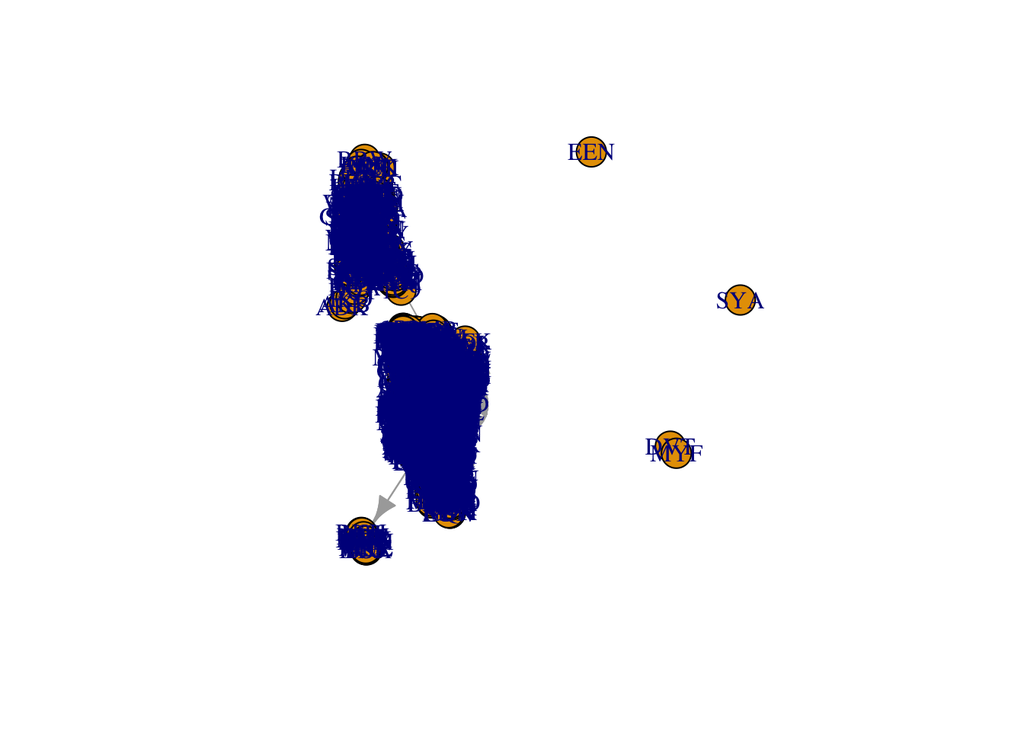

```r
g <- graph_from_data_frame(d = edge_list, directed = T, vertices = node_list)
plot(g)
```

Again, the goal of this workshop isn’t to focus on visualization, but it is important to understand how data manipulation and filtering makes a plotted graph easier to read.

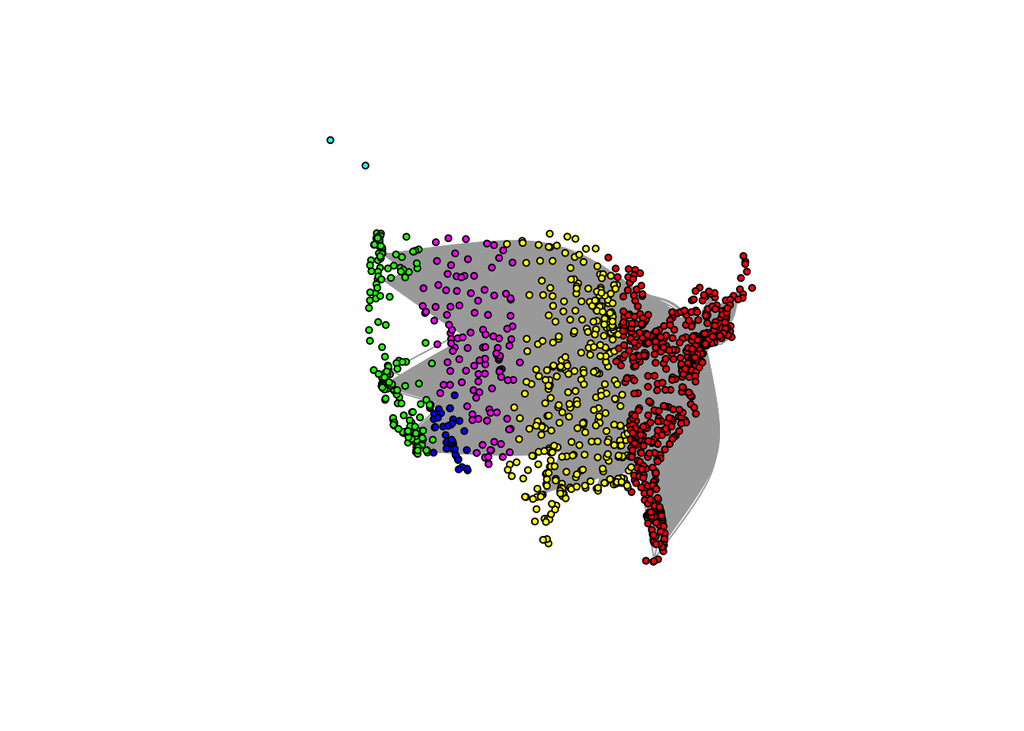

```r
#identify potential attribute to color
conus <- node_list$tzone %>%
  unique %>%
  .[grepl('America', .)] %>%
  .[!grepl('Anchorage', .)]

#create a color palette
clr_palette <- rainbow(length(conus))

#make the color palette callable
names(clr_palette) <- conus

g %>%
  {. - V(.)[!tzone %in% conus]} %>% #remove nodes that arent in the continental US
  {
    V(.)$color <- sapply(V(.)$tzone, function(x){clr_palette[x]});
    .
  } %>%
  plot(
    vertex.size = 3,
    vertex.label = '',
    edge.arrow.size = .1,
    edge.arrow.width = .2
  )
```

Finally, let’s reduce the number of edges by consolidating all the edges that share a similiar origin and similar destination. This is easily done at the preprocessing stage with **dplyr**. We can also get rid of the vertices that don’t have any connections.

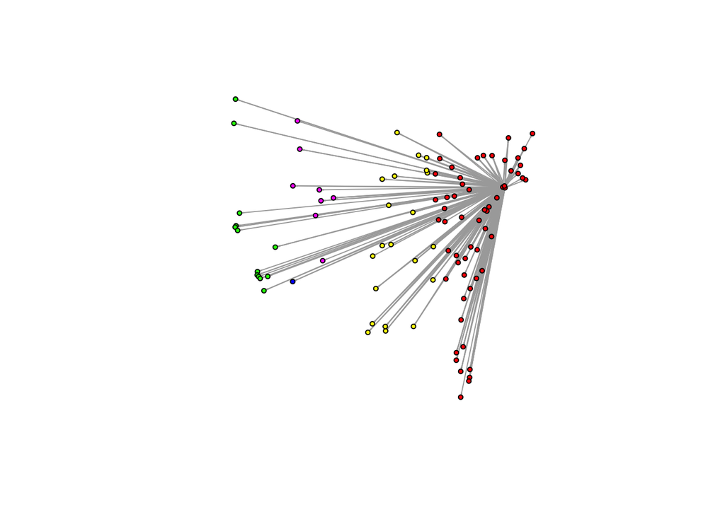

```r
edge_list %>%
  dplyr::count(origin, dest) %>%
  graph_from_data_frame(T, node_list) %>%
  {. - V(.)[!tzone %in% conus]} %>%
  {. - V(.)[degree(.) == 0]} %>% #remove vertices with no connections
  plot(
    vertex.size = 3,
    vertex.label = '',
    vertex.color = sapply(V(.)$tzone, function(x){clr_palette[x]}),
    edge.arrow.size = .1,
    edge.arrow.width = .2
  )
```